# Ch04 Lab KNN Analysis

Bruce Hartman

University of St. Francis

2026-09-09 Revised 2026-10-16T08:36:27

Abstract

We run a knn analysis for classification model with tidy methods following ISLR Chapter 4 Section 4.6.5.

# Introduction

We follow the textbook Chapter 4: Classification, the same as chapter 4.6.5 lab in ISLR text on page 163-164.

Why do we need another method of classification? Before we performed a two-step approach in which we first fit the model and then we use the model to make predictions.

The K-nearest-neighbors (KNN) model, `FNN::knn()` forms predictions using a single command. the version in the `FNN` package works in a tidy manner with data frames.

This is less supervised than using logistic regression; we only have the number of nearest neighbors to consider as a parameter.

The function requires three inputs. Others have defaults.

| Input | Description | Default |
| --- | --- | --- |
| train | matrix or data frame of training set cases. |  |
| test | matrix or data frame of test set cases. A vector will be interpreted as a row vector for a single case. |  |
| cl | factor of true classifications of training set. |  |
| k | number of neighbours considered | default=1 |
| prob | if this is true, the proportion of the votes for the winning class are returned as attribute prob | default=FALSE |
| algorithm | nearest neighbor search algorithm | c(“kd_tree”, “cover_tree”, “brute”) |

A decent simplified source of documentation is Reference 2.

# Research Question

Again we want to predict Down or Up for the S&P 500 based on the data in `Smarket`.

# Packages

```
library(ISLR2) # package with data files
library(FNN) # for knn modeling
library(mbadtools, quietly=TRUE) # used to manipulate data and plot
```

# Data

The data is in the `ISLR2` package.

```
data(Smarket)
Smarket %>% skim()
```

```
── Data Summary ────────────────────────
                           Values
Name                       Piped data
Number of rows             1250
Number of columns          9
_______________________
Column type frequency:
  factor                   1
  numeric                  8
________________________
Group variables            None
```

|  | skim_variable | n_missing | complete_rate | ordered | n_unique | top_counts |
| --- | --- | --- | --- | --- | --- | --- |
| 1 | Direction | 0 | 1 | FALSE | 2 | Up: 648, Dow: 602 |

|  | skim_variable | n_missing | complete_rate | mean | sd | p0 | p25 | p50 | p75 | p100 | hist |
| --- | --- | --- | --- | --- | --- | --- | --- | --- | --- | --- | --- |
| 1 | Year | 0 | 1 | 2003.0160000 | 1.4090182 | 2001.00000 | 2002.0000 | 2003.00000 | 2004.000000 | 2005.00000 | ▇▇▇▇▇ |
| 2 | Lag1 | 0 | 1 | 0.0038344 | 1.1362988 | -4.92200 | -0.6395 | 0.03900 | 0.596750 | 5.73300 | ▁▃▇▁▁ |
| 3 | Lag2 | 0 | 1 | 0.0039192 | 1.1362803 | -4.92200 | -0.6395 | 0.03900 | 0.596750 | 5.73300 | ▁▃▇▁▁ |
| 4 | Lag3 | 0 | 1 | 0.0017160 | 1.1387030 | -4.92200 | -0.6400 | 0.03850 | 0.596750 | 5.73300 | ▁▃▇▁▁ |
| 5 | Lag4 | 0 | 1 | 0.0016360 | 1.1387737 | -4.92200 | -0.6400 | 0.03850 | 0.596750 | 5.73300 | ▁▃▇▁▁ |
| 6 | Lag5 | 0 | 1 | 0.0056096 | 1.1475502 | -4.92200 | -0.6400 | 0.03850 | 0.597000 | 5.73300 | ▁▃▇▁▁ |
| 7 | Volume | 0 | 1 | 1.4783050 | 0.3603571 | 0.35607 | 1.2574 | 1.42295 | 1.641675 | 3.15247 | ▁▇▅▁▁ |
| 8 | Today | 0 | 1 | 0.0031384 | 1.1363341 | -4.92200 | -0.6395 | 0.03850 | 0.596750 | 5.73300 | ▁▃▇▁▁ |

Train on the data through 2004, and test it on the last part of the data in 2005 and beyond.

# Train and Test data

We need a training data set and a test set because we are trying to predict the future from the past. We will train on the train set, any year before 2005; and validate or test using the test dataset.

For KNN we need to separate the drivers from the target. Again we use only 2 lags.

```
#drivers
train.X = Smarket %>% filter (Year<2005) %>% select(Lag1, Lag2)
test.X  = Smarket %>% filter (Year>=2005) %>% select(Lag1, Lag2)
```

```
# target
train.Y = Smarket %>% filter (Year<2005) %>% pull(Direction)
test.Y =  Smarket %>% filter (Year>=2005) %>% pull(Direction)
```

We use `pull()`for the target because we want a vector of the directions.

# Readying KNN

This routine uses some randomization; therefore if you run it twice it won’t come out the same. To make it be reproducible for this paper, you have to set the seed to a specific integer. As long as the seed is set to the same thing it will get the same results. If you let R decide on the seed you might get a different result every time you run.

In practice, you might actually not set the seed, but run it 20 times and ‘average’ the results.

We set seed so it is reproducible, and the reader can match the results.

```
set.seed(1)
```

# Running KNN

Start by having the algorithm investigate only one nearest neighbor. Set the parameter $k=1$. Train on the training data. The output is the classification of the cases.

```
knn.pred = knn(train.X, test.X, train.Y, k=1 )
```

Make confusion matrix of predictions of the trained model on test vs actual test Directions. We will choose the default parameters. The output will be a vector of classifications.

```
tk1 = data.frame(Direction=test.Y, .pred=knn.pred) %>%
  conf_mat(Direction, .pred)
tk1
```

```
          Truth
Prediction Down Up
      Down   43 58
      Up     68 83
```

```
tk1 %>% summary %>% filter(.metric=="accuracy")
```

| .metric | .estimator | .estimate |
| --- | --- | --- |
| accuracy | binary | 0.5 |

The KNN model with 1 nearest neighbor predicts 50% correctly.

Using two nearest neighbors, set $k=2$. Train on the training data.

```
knn.pred2 = FNN::knn(train.X, test.X, train.Y, k=2 )
tk2 = data.frame(Direction=test.Y, .pred=knn.pred2) %>%
  conf_mat(Direction, .pred)
tk2
```

```
          Truth
Prediction Down Up
      Down   74 93
      Up     37 48
```

```
tk2 %>% summary %>% filter(.metric=="accuracy")
```

| .metric | .estimator | .estimate |
| --- | --- | --- |
| accuracy | binary | 0.484127 |

With two nearest neighbors we get 48%.

Using three nearest neighbors, set $k=3$.

```
knn.pred3 = knn(train.X, test.X, train.Y, k=3 )
tk3 = data.frame(Direction=test.Y, .pred=knn.pred3) %>%
  conf_mat(Direction, .pred)
tk3
```

```
          Truth
Prediction Down Up
      Down   48 55
      Up     63 86
```

```
tk3 %>% summary %>% filter(.metric=="accuracy")
```

| .metric | .estimator | .estimate |
| --- | --- | --- |
| accuracy | binary | 0.531746 |

With three nearest neighbors we get 53.2% correct.

Using four nearest neighbors, set $k=4$. Train on the training data.

```
knn.pred4 = knn(train.X, test.X, train.Y, k=4 )
tk4 = data.frame(Direction=test.Y, .pred=knn.pred4) %>%
  conf_mat(Direction, .pred)
tk4
```

```
          Truth
Prediction Down Up
      Down   71 82
      Up     40 59
```

```
tk4 %>% summary %>% filter(.metric=="accuracy")
```

| .metric | .estimator | .estimate |
| --- | --- | --- |
| accuracy | binary | 0.515873 |

With four nearest neighbors we get 51.6% correct.

# Visualization

We take this discussion from Reference 3. WE use the result of k=3, because it had the highest accuracy. First we simply make the two dot plots, showing that it is hard to separate two clusters. We use the system-defined colors to show the two classes. We set the colors to be the two values in test.Y.

```
z = case_when(knn.pred3==test.Y ~ "right",
              .default = "wrong")
wrap_plots(nrow=1, guides='collect',
  ggplot(test.X) +
    geom_point(aes(Lag1, Lag2, color=test.Y)) +
    labs(title = "Cluster Plots",
         subtitle = "Observed classes")+
    theme_bw()
  ,
  ggplot(test.X) +
    geom_point(aes(Lag1, Lag2, color=z)) +
    scale_color_manual(name="Match", values=c("black","red")) +
    labs(subtitle="Predicted classes")+
    theme_bw()
)
```

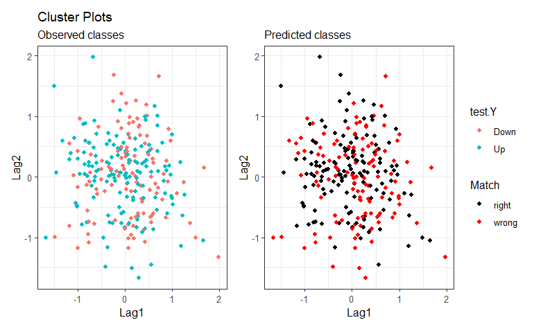

# Conclusion

We used `FNN::knn` to model the classification of the test dataset after building a model with the training dataset.

# References

1. ISLR (2013) Chapter 4: Classification, Section 4.6.5, page 163ff.
3. Shengqiao Li (2023) [Package FNN in R](https://cran.r-project.org/web/packages/FNN/FNN.pdf)
3. [Clustering Visualization with ggplot](https://www.datanovia.com/en/blog/k-means-clustering-visualization-in-r-step-by-step-guide/) (https://www.datanovia.com/en/blog/k-means-clustering-visualization-in-r-step-by-step-guide/)
2. [knn in R](https://towardsdatascience.com/k-nearest-neighbors-algorithm-with-examples-in-r-simply-explained-knn-1f2c88da405c) (https://towardsdatascience.com/k-nearest-neighbors-algorithm-with-examples-in-r-simply-explained-knn-1f2c88da405c)